# Chapter 2: Bayesian Methods and WinBUGS

Bob

2025-02-25

```r
library('rjags')
library('coda')
library('jagshelper')
library('jagsUI')
```

```r
library('mcmcplots')  # caterplot
library('dplyr')
setwd("~/Documents/projects/Healthcare_Technology_Assessment/ARSCESDMH")
```

# `BLOCKER.txt`

## BLOCKER EG - Modelling log(Odds Ratio)

```r
# Model

model_code <- "model {
  # Likelihood
  for (j in 1:Nstud) {
    P[j] <- 1/V[j]      # Calculate precision
    Y[j] ~ dnorm(delta[j],P[j])
    delta[j] ~ dnorm(d,prec)
  }

  # Priors
  d ~ dnorm(0,1.0E-6)
  prec <- 1/tau.sq
  tau.sq <- tau*tau   # tau.sq = between-study variance
  tau ~ dunif(0,10)   # Uniform on SD
}" %>% textConnection


# Starting/initial values

initial_values <- list(list(
  delta=c(0,0,0,0,0,0,0,0,0,0,0,0,0,0,0,0,0,0,0,0,0,0),
  d=0,
  tau=1
))


# Data
# The data is inline below, but if you want to read it from the original excel file, you could do this:
# library('readxl')
# data <- read_excel("BLOCKER.xls") %>% as.list
# data['Nstud'] <- 22

data <- "Y  V
0.02817088  0.72301587
-0.7410032  0.23343543
-0.5406212  0.31872921
-0.24612808 0.01909462
0.06945337  0.07876801
-0.5841569  0.45658762
-0.51238549 0.01923431
-0.07862326 0.04161232
-0.42417337 0.07506123
-0.3348234  0.01370499
-0.21339753 0.0379751
-0.03890844 0.05265218
-0.59325371 0.18076732
0.28154593  0.04220784
-0.32133359 0.08863069
-0.13534792 0.06808023
0.14060645  0.13262283
0.32204972  0.30541643
0.44438052  0.51358597
-0.21750973 0.0675177
-0.59107599 0.06615537
-0.60809913 0.07419013" %>%
  read.delim(text=., sep='\t') %>%
  as.list

data['Nstud'] <- length(data[['V']])

out_initial <- jags(data = data,
            inits = initial_values,
            parameters.to.save = c("d", "tau"),
            model.file = model_code,
            n.chains = length(initial_values),
            n.adapt = 100,
            n.iter = 30000,
            n.burnin = 20000,
            n.thin = 2)
```

```
##
## Processing function input.......
##
## Done.
##
##
##
## Adaptive phase, 100 iterations x 1 chains
## If no progress bar appears JAGS has decided not to adapt
##
##
##  Burn-in phase, 20000 iterations x 1 chains
##
##
## Sampling from joint posterior, 10000 iterations x 1 chains
##
##
## Calculating statistics.......
##
## Done.
```

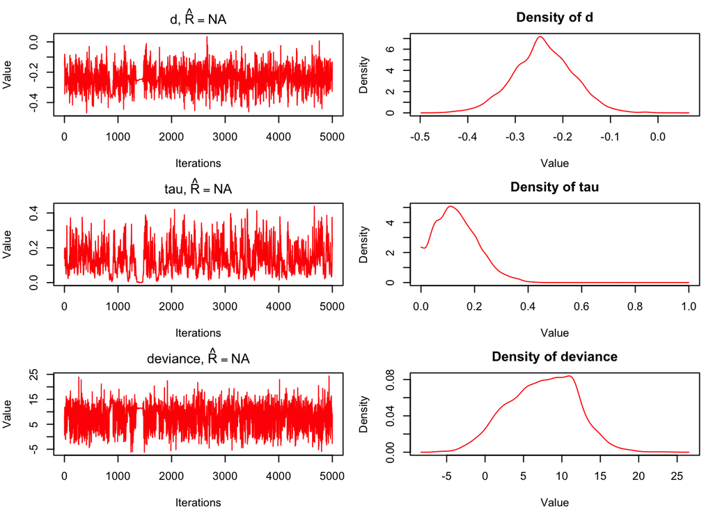

```r
plot(out_initial)
```

# `BLOCKER_binomial.txt`

BLOCKER EG - Modelling binomial data, as per WinBUGS examples, vol I Note: some of the variance/precision parameter names are different to the code in the WinBUGS example blocker file.

```r
model_code <- "
model {
  for( j in 1 : Nstud ) {
    # Binomial Likelihood
    rc[j] ~ dbin(pc[j], nc[j])
    rt[j] ~ dbin(pt[j], nt[j])
    logit(pc[j]) <- mu[j]
    logit(pt[j]) <- mu[j] + delta[j]   # delta[j] is the log odds ratio in jth study
    mu[j] ~ dnorm(0.0,1.0E-5)
    delta[j] ~ dnorm(d, prec)      # d = pooled log odds ratio & prec = between-study precision
  }

  # Priors
  d ~ dnorm(0.0,1.0E-6)
  prec <- 1/tau.sq
  tau.sq <- tau*tau        # tau = between-study standard deviation
  tau ~ dunif(0,10)          # Uniform prior on SD

  # Calculate overall pooled Odds Ratio (OR)
  OR <- exp(d)

  # Calculate probability that the pooled OR > 1
  prob.OR1 <- step(d)
}
" %>% textConnection
```

```r
# Data
data <- list(
  rt = c(3,  7,  5,  102,  28, 4,  98,  60, 25, 138, 64, 45,  9, 57, 25, 33, 28, 8, 6, 32, 27, 22 ),
  nt = c(38, 114, 69, 1533, 355, 59, 945, 632, 278,1916, 873, 263, 291, 858, 154, 207, 251, 151, 174, 209, 391, 680),
  rc = c(3, 14, 11, 127, 27, 6, 152, 48, 37, 188, 52, 47, 16, 45, 31, 38, 12, 6, 3, 40, 43, 39),
  nc = c(39, 116, 93, 1520, 365, 52, 939, 471, 282, 1921, 583, 266, 293, 883, 147, 213, 122, 154, 134, 218, 364, 674),
  Nstud = 22)

initial_values <- list(
  list(
    d = 0.5,
    tau=0.5,
    mu = c(0, 0, 0, 0, 0, 0, 0, 0, 0, 0, 0, 0, 0, 0, 0, 0, 0, 0, 0, 0, 0, 0),
    delta = c(0, 0, 0, 0, 0, 0, 0, 0, 0, 0, 0, 0, 0, 0, 0, 0, 0, 0, 0, 0, 0, 0)
  )
)

for (i in 1:3){
  new_inits <- list(
    d = 0,
    tau=1,
    mu = runif(data$Nstud),
    delta = runif(data$Nstud)
  )

  initial_values <- append(initial_values, list(new_inits))
}

results <- jags(data = data,
            inits = initial_values,
            parameters.to.save = c("OR", "d", "tau"),
            model.file = model_code,
            n.chains = length(initial_values),
            n.adapt = 100,
            n.iter = 60000,
            n.burnin = 30000,
            n.thin = 2)
```

```
##
## Processing function input.......
##
## Done.
##
##
##
## Adaptive phase, 100 iterations x 4 chains
## If no progress bar appears JAGS has decided not to adapt
##
##
##  Burn-in phase, 30000 iterations x 4 chains
##
##
## Sampling from joint posterior, 30000 iterations x 4 chains
##
##
## Calculating statistics.......
##
## Done.
```

```r
summary(results)
```

```
##                 mean         sd         2.5%          25%         50%
## OR         0.7815235 0.05208949   0.68614276   0.74622743   0.7789682
## d         -0.2487148 0.06633037  -0.37666957  -0.29272486  -0.2497850
## tau        0.1409292 0.07987234   0.01514082   0.08132729   0.1333933
## deviance 259.0239619 8.09776597 244.40798184 253.38277815 258.6371711
##                  75%       97.5%     Rhat n.eff overlap0         f
## OR         0.8138977   0.8913502 1.001098  2528        0 1.0000000
## d         -0.2059206  -0.1150179 1.001108  2478        0 0.9994167
## tau        0.1903487   0.3198087 1.004099   616        0 1.0000000
## deviance 264.2012935 276.1664157 1.000465  5162        0 1.0000000
```

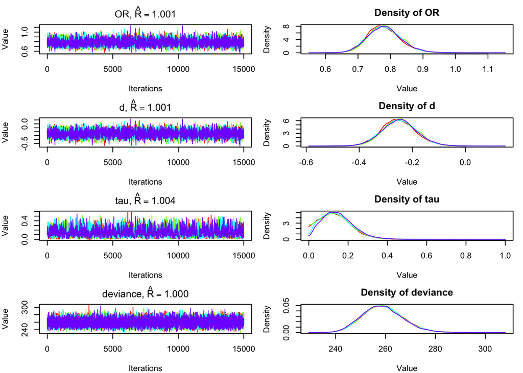

```r
plot(results)
```

# `blocker_with_results.txt`

## BLOCKER EG - Modelling log(Odds Ratio)

Using multiple chains to assess convergence

```r
model_code <- "
model {
  # Likelihood
  for (j in 1:Nstud) {
    P[j] <- 1/V[j]
    Y[j] ~ dnorm(delta[j],P[j])
    delta[j] ~ dnorm(d, prec)
  }

  # Priors
  d ~ dnorm(0,1.0E-6)
  prec <- 1/tau.sq
  tau.sq <- tau*tau
  tau ~ dunif(0,10)

  # Calculate OR & prob OR>1
  OR <- exp(d)
  prob.OR1 <- step(d)

  #Set delta[26] = d for caterpillar plot
  delta[26] <- d
}" %>% textConnection

initial_values <- list(
  # Chain 1
  list(delta=c(0,0,0,0,0,0,0,0,0,0,0,0,0,0,0,0,0,0,0,0,0,0, NA,NA,NA,NA),
       d=0,
       tau=1),

  # Chain 2
  list(delta=c(10,10,10,10,10,10,10,10,10,10,10,10,10,10,10,10,10,10,10,10,10,10, NA,NA,NA,NA),
       d=-10,
       tau=8)
)

data <- list(
  Y=c(0.02817088,-0.74100320,-0.54062120,-0.24612808,0.06945337,-0.58415690,
    -0.51238549,-0.07862326,-0.42417337,-0.33482340,-0.21339753,-0.03890844,
    -0.59325371,0.28154593,-0.32133359,-0.13534792,0.14060645,0.32204972,
    0.44438052,-0.21750973,-0.59107599,-0.60809913),
  V=c(0.72301587,0.23343543,0.31872921,0.01909462, 0.07876801, 0.45658762,
      0.01923431, 0.04161232, 0.07506123, 0.01370499, 0.03797510, 0.05265218,
      0.18076732, 0.04220784, 0.08863069, 0.06808023, 0.13262283, 0.30541643,
      0.51358597, 0.06751770, 0.06615537, 0.07419013),
  Nstud=22
)

out_eg <- jags(data = data,
            inits = initial_values,
            parameters.to.save = c("OR", "d", "tau", "delta"),
            model.file = model_code,
            n.chains = length(initial_values),
            n.adapt = 100,
            n.iter = 30000,
            n.burnin = 20000,
            n.thin = 2)
```

```
##
## Processing function input.......
##
## Done.
##
##
##
## Adaptive phase, 100 iterations x 2 chains
## If no progress bar appears JAGS has decided not to adapt
##
##
##  Burn-in phase, 20000 iterations x 2 chains
##
##
## Sampling from joint posterior, 10000 iterations x 2 chains
##
##
## Calculating statistics.......
##
## Done.
```

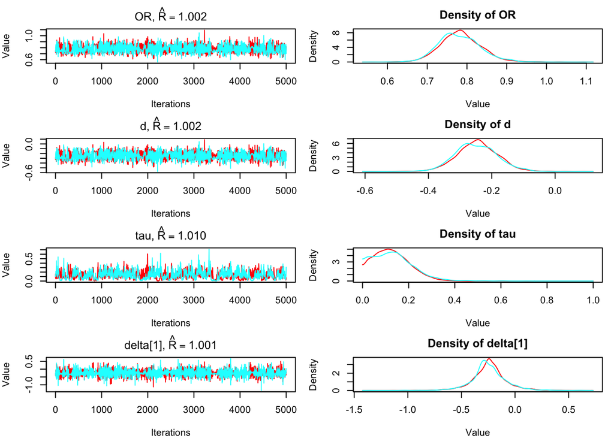

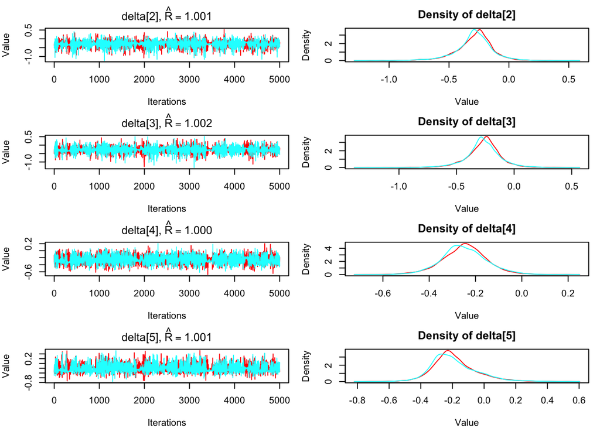

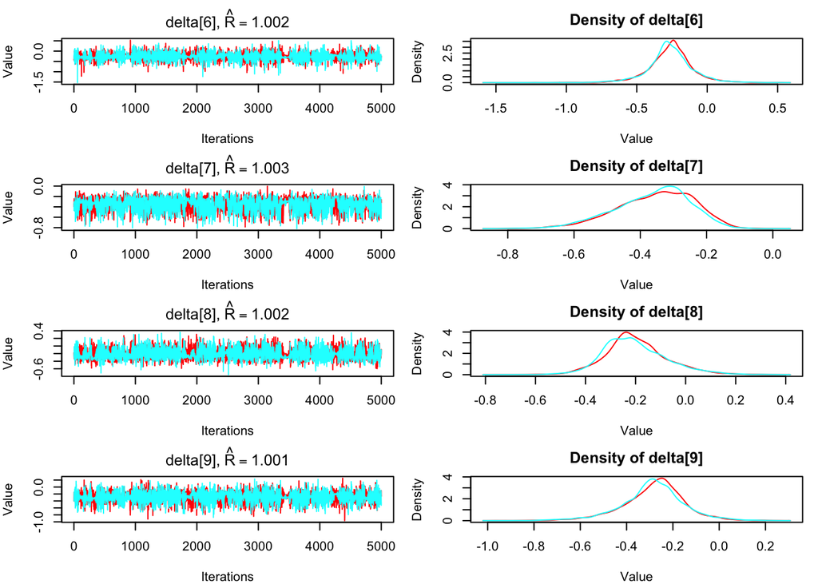

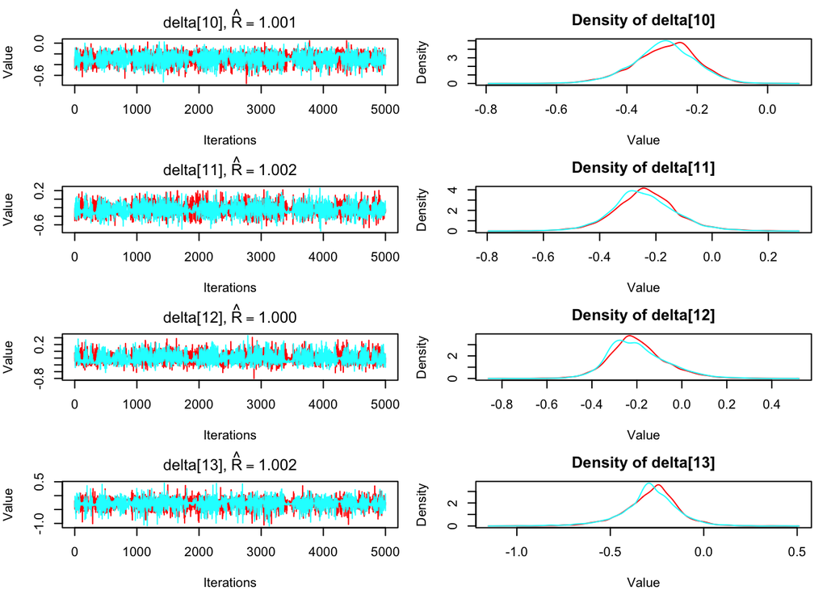

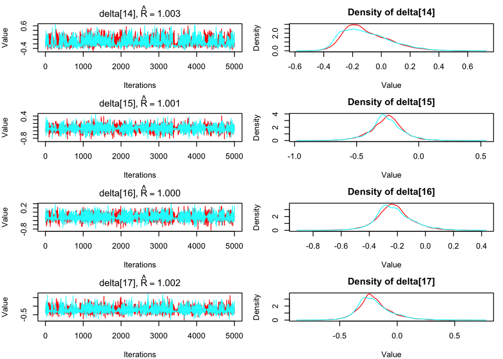

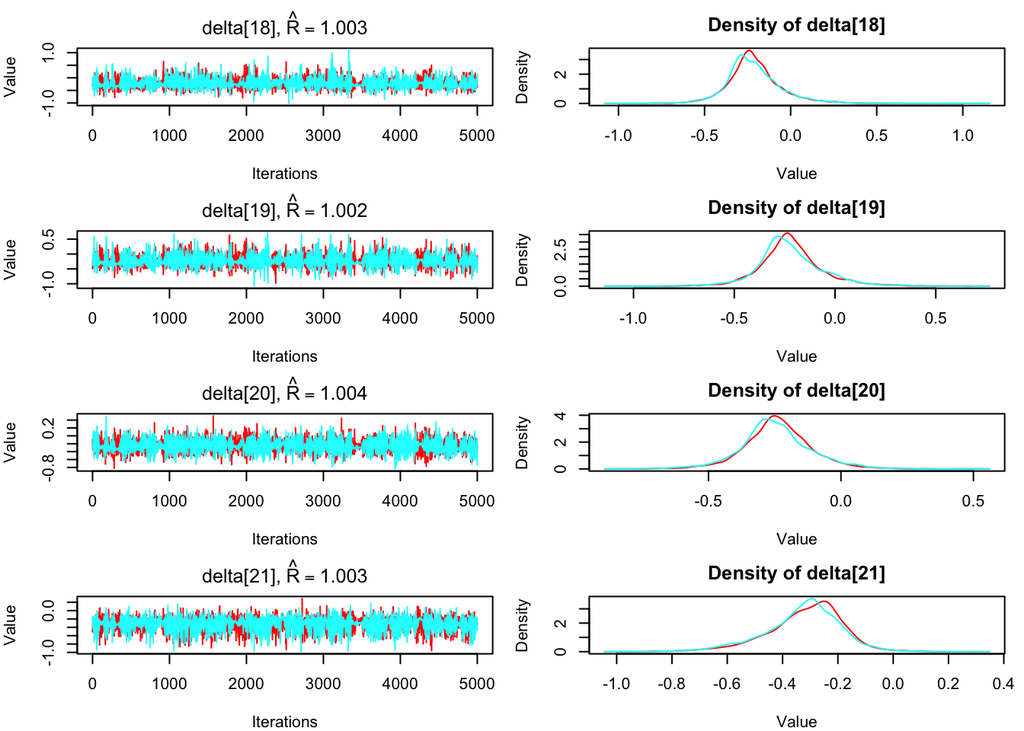

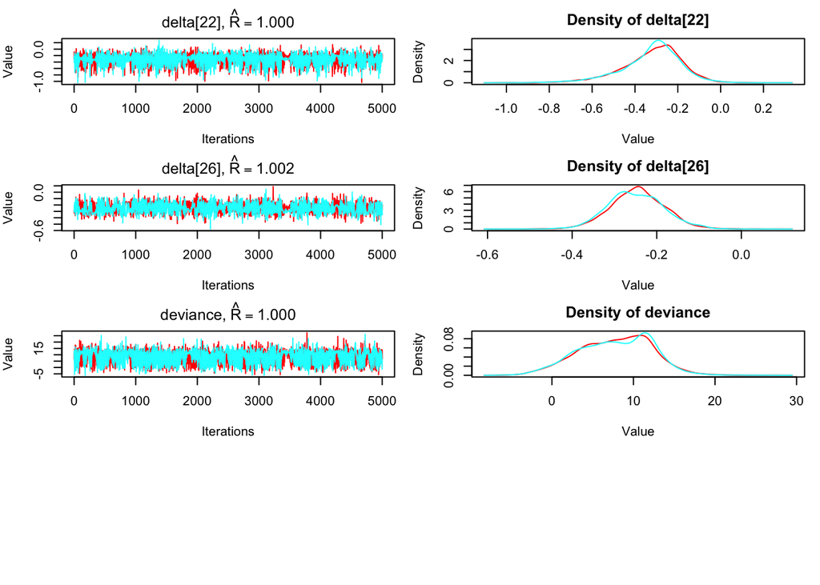

```r
plot(out_eg)
```

```r
# densityplot(out)
```

These are the comments from the results of the WinBUGS file:

“The summary statistics for the 2 chains using a burn-in of 20,000 iterations and a sample of length 10,000 iterations are very similar despite the very different starting values suggesting that the chains have converged.

The BGR statistics are also suggestive of the chains having converged - the green (pooled) and blue (individual chains) widths of the 80% CrIs are relatively stable, and their ratio (red line) is approximately 1.

The actual samples from the 2 chains are also very similar as can be seen on the history plots below for d and tau.”

## TO DO:

How do we make a caterpillar plot from the delta and d values? Note that the model copied the value for ‘d’ into the delta vector (`delta[26] <- d`), which was a hack to put all of these values in the same vector for plotting. We might not need to do this.

We want these values ordered by name; they seem to be ordered by decreasing value of the median.

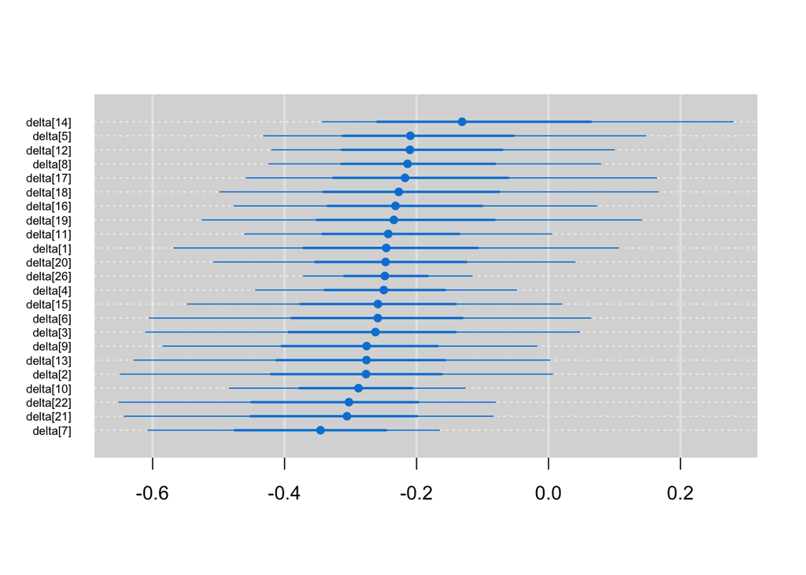

```r
colnames <- sprintf("delta[%d]", c(1:22, 26))
caterplot(out_eg$samples[, colnames])
```

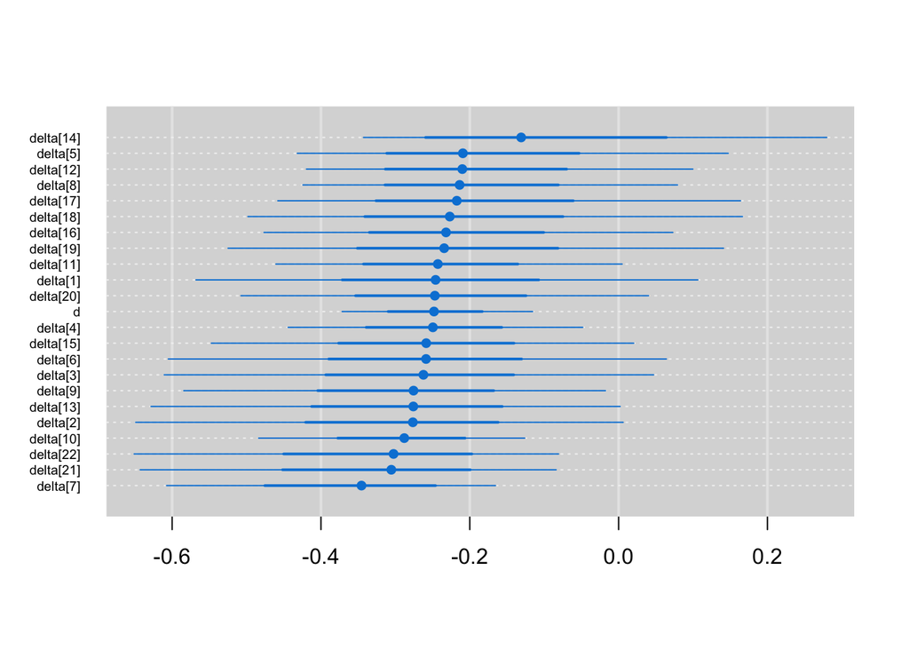

```r
colnames <- c(sprintf("delta[%d]", 1:22), 'd')
caterplot(out_eg$samples[, colnames])
```